# Introduction to VPRMLandSfcModel.

The VPRMLandSfcModel R package provides a pure R implementation of the Vegetation Photosynthesis and Respiration Model (VPRM) of [Mahadevan et al. (2008)](https://doi.org/10.1029/2006GB002735), along with tools for assembling VPRM driver data and estimating model parameter values.

The following examples illustrate how to use the VPRMLandSfcModel R package. The documentation for individual functions explains their purpose, output, and arguments in much more detail.

## Usage Example: assembling VPRM driver data

VPRMLandSfcModel can accept input data as either an R data frame or as an object of class VPRM_driver_data. Using the included dataset `ParkFalls`, run the VPRM for the [Park Falls, Wisconsin, USA Ameriflux site](http://ameriflux.lbl.gov/sites/siteinfo/US-PFa):

```r
library(VPRMLandSfcModel)
data(Park_Falls)
## determine the phenology phase for each tower observation date
phen_filled <- interp_phenology(PFa_phen, PFa_tower_obs[['date']])
## place the tower observations and MODIS data into a VPRM_driver_data object.
pfa_dd <- VPRM_driver_data(name_long="Park Falls",
                           name_short = "US-PFa",
                           lat=45.9459,
                           lon=-90.2723,
                           PFT='MF',    ## mixed forest
                           tower_date=PFa_tower_obs[['date']],
                           NEE_obs=PFa_tower_obs[['FC']],
                           T=PFa_tower_obs[['TA']],
                           PAR=PFa_tower_obs[['PAR']],
                           date_nir = PFa_refl[['date']],
                           rho_nir=PFa_refl[['nir']],
                           date_swir = PFa_refl[['date']],
                           rho_swir = PFa_refl[['swir']],
                           date_EVI = PFa_evi[['date']],
                           EVI=PFa_evi[['evi']],
                           phen=phen_filled)
## take a look at the result
print(head(as.data.frame(pfa_dd)))
```

```
##                  date NEE_obs      T     PAR   rho_nir  rho_swir       EVI
## 1 (01/02/05 04:00:00)      NA -13.29   0.000 0.1670460 0.1417629 0.4303005
## 2 (01/02/05 05:00:00)      NA -12.90   0.000 0.1670563 0.1417782 0.4299233
## 3 (01/02/05 06:00:00)   0.871 -12.11   0.000 0.1670666 0.1417936 0.4295461
## 4 (01/02/05 07:00:00)   0.855 -11.13   0.000 0.1670769 0.1418089 0.4291689
## 5 (01/02/05 08:00:00)   0.501 -10.86  54.094 0.1670872 0.1418243 0.4287917
## 6 (01/02/05 09:00:00)   0.121 -10.17 178.138 0.1670975 0.1418397 0.4284145
##   phen       LSWI Tscale    Pscale    Wscale  Tresp
## 1 gmin 0.08187307      0 0.5409365 0.8051746 -13.29
## 2 gmin 0.08184990      0 0.5409250 0.8051573 -12.90
## 3 gmin 0.08182674      0 0.5409134 0.8051401 -12.11
## 4 gmin 0.08180357      0 0.5409018 0.8051228 -11.13
## 5 gmin 0.08178042      0 0.5408902 0.8051056 -10.86
## 6 gmin 0.08175726      0 0.5408786 0.8050884 -10.17
```

Now plot air temperature. The [ggplot2](http://ggplot2.tidyverse.org) package is not necessary to install or use VPRMLandSfcModel, but it makes very pretty plots.

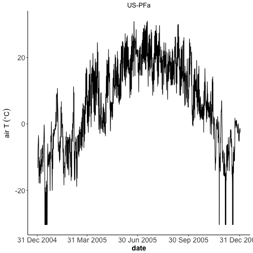

```r
library(ggplot2)
library(chron)
##
fig_T <- (ggplot(pfa_dd[['data']],
              aes(date, T)) +
        geom_line() +
        scale_x_chron(format="%d %b %Y") +
        labs(title = "US-PFa", y=expression(air~T~(degree*C))) +
        theme_classic() +
        theme(plot.title = element_text(hjust = 0.5)) +    # center the plot title
        theme(axis.text=element_text(size=14),
            axis.title=element_text(size=14,face="bold")))
print(fig_T)
```

## Usage Example: calculating VPRM NEE

Calculating VPRM fluxes requires values for the parameters lambda, PAR\(_0\), alpha, and beta. The dataset VPRM_parameters, part of the VPRMLandSfcModel package, includes several parameters sets.

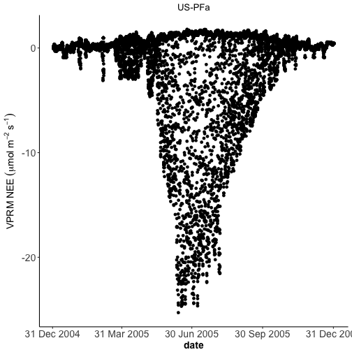

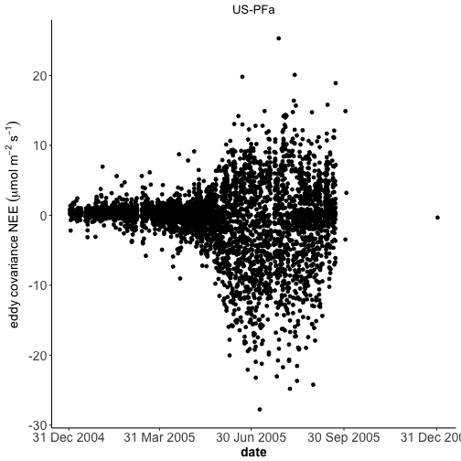

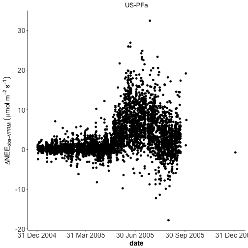

```r
data(VPRM_parameters)
attach(all_all_VPRM_parameters)
pfa_dd[['data']][['VPRM_NEE']] <- vprm_calc_NEE(
    pfa_dd, lambda=lambda, PAR_0=PAR_0, alpha=alpha, beta=beta)

fig_NEE_VPRM <- (ggplot(pfa_dd[['data']],
    aes(date, VPRM_NEE)) +
    geom_point() +
    scale_x_chron(format="%d %b %Y") +
    labs(title = "US-PFa", x='date', y=expression(VPRM~NEE~(mu*mol~m^{-2}~s^{-1}))) +
    theme_classic() +
    theme(plot.title = element_text(hjust = 0.5)) +    # center the plot title
    theme(axis.text=element_text(size=14),
        axis.title=element_text(size=14,face="bold")))
print(fig_NEE_VPRM)

## now plot the eddy covariance-observed NEE
fig_NEE_EC <- (ggplot(pfa_dd[['data']],
    aes(date, NEE_obs)) +
    geom_point() +
    scale_x_chron(format="%d %b %Y") +
    labs(title = "US-PFa", x='date',
        y=expression(eddy~covariance~NEE~(mu*mol~m^{-2}~s^{-1}))) +
    theme_classic() +
    theme(plot.title = element_text(hjust = 0.5)) +    # center the plot title
    theme(axis.text=element_text(size=14),
        axis.title=element_text(size=14,face="bold")))
print(fig_NEE_EC)
## now plot the difference between covariance-observed NEE and VPRM NEE
fig_dNEE <- (ggplot(pfa_dd[['data']],
    aes(date, NEE_obs-VPRM_NEE)) +
    geom_point() +
    scale_x_chron(format="%d %b %Y") +
    labs(title = "US-PFa", x='date',
        y=expression(Delta*NEE[obs-VPRM]~(mu*mol~m^{-2}~s^{-1}))) +
    theme_classic() +
    theme(plot.title = element_text(hjust = 0.5)) +    # center the plot title
    theme(axis.text=element_text(size=14),
        axis.title=element_text(size=14,face="bold")))
print(fig_dNEE)
```

The difference between the eddy covariance NEE and the VPRM NEE illustrates that the all-all VPRM parameter set from [Hilton et al. (2013)](https://www.biogeosciences.net/10/4607/2013/) isn't the best choice (except for ease of use). [Hilton et al (2014)](https://www.biogeosciences.net/11/217/2014/) discusses different spatial and temporal groupings of data for parameter estimation and concludes that grouping by plant functional types, perhaps in annual windows, minimizes model error among the options considered.

# Usage Example: estimating VPRM parameters

The following code estimates two sets of parameter values for the [Park Falls, Wisconsin Ameriflux site](http://ameriflux.lbl.gov/sites/siteinfo/US-PFa) using the methodology described in [Hilton et al. (2013)](https://www.biogeosciences.net/10/4607/2013/). The first set estimates values for the entire year. The second estimates monthly values, creating 12 sets of values for [lamba, PAR_0, alpha, beta].

The examples below set DE_itermax to a very low value (2) so that the examples run quickly. To obtain useful parameter estimates, DE_itermax must be set much larger. 500 to 1000 is usually a good starting point.

```r
library(VPRMLandSfcModel)
library(DEoptim)
data(Park_Falls)
pfa_dd <- VPRM_driver_data(name_long="Park Falls",
                           name_short = "US-PFa",
                           lat=45.9459,
                           lon=-90.2723,
                           PFT='MF',
                           tower_date=PFa_tower_obs[['date']],
                           NEE_obs=PFa_tower_obs[['FC']],
                           T=PFa_tower_obs[['TA']],
                           PAR=PFa_tower_obs[['PAR']],
                           date_nir = PFa_refl[['date']],
                           rho_nir=PFa_refl[['nir']],
                           date_swir = PFa_refl[['date']],
                           rho_swir = PFa_refl[['swir']],
                           date_EVI = PFa_evi[['date']],
                           EVI=PFa_evi[['evi']],
                           phen=NA)

## estimate parameter values for all data
par_est_status <- estimate_VPRM_pars(all_data=pfa_dd[['data']],
                                     DE_itermax = 2,
                                     par_set_str='ExampleRun')
```

```
## list elements for DE:  1
## list names:  all
## within optimizeVPRM_DE:
## lambda_prior:  0 1.5
## alpha_prior:  0 1.5
## beta_prior:  -4 4
## PAR0_prior:  0.1 6000
## upper:  1.5 1.5 4 6000
## lower:  0 0 -4 0.1
## -------
## beginning  all
## Iteration: 1 bestvalit: 148498.347183 bestmemit:    1.251202    0.287344   -3.050658    4.991593
## Iteration: 2 bestvalit: 147124.804668 bestmemit:    1.251202    0.287344   -2.722206    4.991593
## wrote /Users/tim/work/Code/VPRM/VPRM_Rpkg/vignettes/ParEst_ExampleRun.de.RData
```

```r
## estimate parameter values for monthly windows
par_est_status <-
    estimate_VPRM_pars(all_data=pfa_dd[['data']],
                       DE_itermax = 2,
                       par_set_str='ExampleRun_Monthly',
                       opt_groups=months(pfa_dd[['data']][['date']]))
```

```
## list elements for DE:  12
## list names:  Jan Feb Mar Apr May Jun Jul Aug Sep Oct Nov Dec
## within optimizeVPRM_DE:
## lambda_prior:  0 1.5
## alpha_prior:  0 1.5
## beta_prior:  -4 4
## PAR0_prior:  0.1 6000
## upper:  1.5 1.5 4 6000
## lower:  0 0 -4 0.1
## -------
## beginning  Jan
## Iteration: 1 bestvalit: 913.920758 bestmemit:    0.695707    0.198053    1.519300 2086.321856
## Iteration: 2 bestvalit: 396.320122 bestmemit:    0.493528    0.143856    1.759896 1292.200790
## within optimizeVPRM_DE:
## lambda_prior:  0 1.5
## alpha_prior:  0 1.5
## beta_prior:  -4 4
## PAR0_prior:  0.1 6000
## upper:  1.5 1.5 4 6000
## lower:  0 0 -4 0.1
## -------
## beginning  Feb
## Iteration: 1 bestvalit: 2958.492421 bestmemit:    0.078654    0.433998    2.292077 1249.940866
## Iteration: 2 bestvalit: 859.260706 bestmemit:    0.126054    0.152468    1.492049 2844.286476
## within optimizeVPRM_DE:
## lambda_prior:  0 1.5
## alpha_prior:  0 1.5
## beta_prior:  -4 4
## PAR0_prior:  0.1 6000
## upper:  1.5 1.5 4 6000
## lower:  0 0 -4 0.1
## -------
## beginning  Mar
## Iteration: 1 bestvalit: 1273.483626 bestmemit:    0.014849    0.158247    1.223161 1543.028706
## Iteration: 2 bestvalit: 1273.483626 bestmemit:    0.014849    0.158247    1.223161 1543.028706
## within optimizeVPRM_DE:
## lambda_prior:  0 1.5
## alpha_prior:  0 1.5
## beta_prior:  -4 4
## PAR0_prior:  0.1 6000
```

[output cut: 80 more lines]

```
## beginning  Nov
## Iteration: 1 bestvalit: 100000000000000000000.000000 bestmemit:    0.818907    0.678954    1.047139 3761.222294
## Iteration: 2 bestvalit: 100000000000000000000.000000 bestmemit:    0.818907    0.678954    0.568939 1491.032194
## within optimizeVPRM_DE:
## lambda_prior:  0 1.5
## alpha_prior:  0 1.5
## beta_prior:  -4 4
## PAR0_prior:  0.1 6000
## upper:  1.5 1.5 4 6000
## lower:  0 0 -4 0.1
## -------
## beginning  Dec
## Iteration: 1 bestvalit: 100000000000000000000.000000 bestmemit:    1.189008    0.068430   -2.288309 3611.018480
## Iteration: 2 bestvalit: 100000000000000000000.000000 bestmemit:    1.189008    0.350543   -3.204502 5942.239251
## wrote /Users/tim/work/Code/VPRM/VPRM_Rpkg/vignettes/ParEst_ExampleRun_Monthly.de.RData
```

`estimate_VPRM_pars` writes the best-fit parameter values to an RData file in the working directory. After the parameter estimation completes, load the RData file into the workspace to have a look. The optimized parameters are a collection of objects of class DEoptim. See the documentation for the [DEoptim package](https://cran.r-project.org/package=DEoptim) for details. The best-fit values are in the field optim$bestmem.

```r
attach('ParEst_ExampleRun_Monthly.de.RData')
ls(2)
```

```
##  [1] "Apr" "Aug" "Dec" "Feb" "Jan" "Jul" "Jun" "Mar" "May" "Nov" "Oct"
## [12] "Sep"
```

```r
print(Apr[['optim']][['bestmem']])
```

```
##       lambda        alpha         beta        PAR_0
##   0.37716753   0.23933773  -0.02959766 116.40206793
```